# Assignment_Week3

Hangsoo Jeong

9/23/2020

```r
library(ggplot2)
library(tidyverse)
library(tidycensus)
tract_data <- read_csv("people.csv")
```

### Topic Reminder.

I want to explore the relationship between income, travel time to work, Workload level, sex, and Housing tenure type at the person-level in Massachusetts.

## Relationship between continuous variables; income and travel time to work.

First, I will test the relationship between my continuous variables - income and travel time to work - by running a correlation test.

```r
correlation1 <- cor.test(tract_data$PINCP, tract_data$JWMNP)
correlation1
```

```
##
##  Pearson's product-moment correlation
##
## data:  tract_data$PINCP and tract_data$JWMNP
## t = 26.057, df = 33439, p-value < 2.2e-16
## alternative hypothesis: true correlation is not equal to 0
## 95 percent confidence interval:
##  0.1305491 0.1515585
## sample estimates:
##       cor
## 0.1410697
```

Based on the Pearson’s r(or correlation coefficient) and p-values for the correlation tests above, a correlation close to +0 indicates a week linear relationship between the variables. Also, its positive correlation at a 95% confidence level. A p-value lower than the conventional 5% (P<0.05) demonstrates its statistically significance.

I want to see what this relationship looks like, so I chose to represent this on a scatterplot.

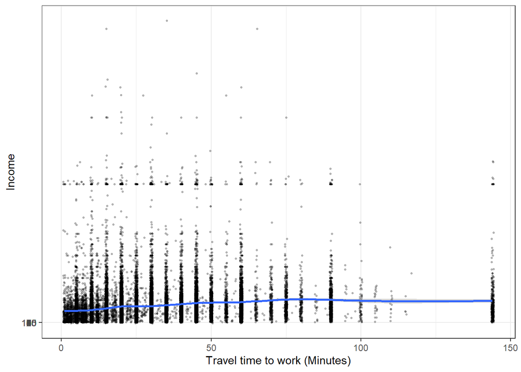

```r
ggplot(tract_data, aes(x = JWMNP, y = PINCP)) +
    geom_point(size = 0.5, alpha = 0.25, position = "jitter") +
    geom_smooth() +
    theme_bw() +
    scale_x_continuous(name = "Travel time to work (Minutes)") +
    scale_y_continuous(name = "Income",
                      breaks = seq(0, 105, by = 5),
                      labels = paste("",
                                  prettyNum(seq(0, 105, by = 5),
                                            big.mark = ",")))
```

## Relationship between categorical variables; Workload level and housing tenure type.

I use the chi-square test of association to determine whether there is a statistically significant association between Workload level and housing tenure type.

```r
chi_sq <- chisq.test(tract_data$workload, tract_data$TEN_label)
chi_sq
```

```
##
##  Pearson's Chi-squared test
##
## data:  tract_data$workload and tract_data$TEN_label
## X-squared = 2503.5, df = 8, p-value < 2.2e-16
```

```r
chi_sq$observed
```

```
##                    tract_data$TEN_label
## tract_data$workload N/A (GQ/vacant) Occupied without payment of rent
##              Heavy               93                               61
##              Light              637                               44
##              Medium             327                              169
##                    tract_data$TEN_label
## tract_data$workload Owned free and clear
##              Heavy                  1246
##              Light                   753
##              Medium                 2882
##                    tract_data$TEN_label
## tract_data$workload Owned with mortgage or loan (include home equity loans)
##              Heavy                                                     5814
##              Light                                                     1840
##              Medium                                                   10467
##                    tract_data$TEN_label
## tract_data$workload Rented
##              Heavy    2425
##              Light     923
##              Medium   5760
```

```r
chi_sq$expected
```

```
##                    tract_data$TEN_label
## tract_data$workload N/A (GQ/vacant) Occupied without payment of rent
##              Heavy         304.6686                         78.97748
##              Light         132.6584                         34.38827
##              Medium        619.6730                        160.63425
##                    tract_data$TEN_label
## tract_data$workload Owned free and clear
##              Heavy             1406.8945
##              Light              612.5881
##              Medium            2861.5174
##                    tract_data$TEN_label
## tract_data$workload Owned with mortgage or loan (include home equity loans)
##              Heavy                                                 5223.179
##              Light                                                 2274.269
##              Medium                                               10623.552
##                    tract_data$TEN_label
## tract_data$workload   Rented
##              Heavy  2625.281
##              Light  1143.096
##              Medium 5339.623
```

I see that there is no category violates the chi-square observed table, as it has a value more than 5. Also, With a p-value so much less than 0.05, we can assume a statistically significant relationship between workload level and housing tenure type at a 95% confidence level.

## Relationships between categorical variables; Workload level and sex.

I use the chi-square test of association to determine whether there is a statistically significant association between Workload level and sex.

```r
chi_sq <- chisq.test(tract_data$workload, tract_data$SEX_label)
chi_sq
```

```
##
##  Pearson's Chi-squared test
##
## data:  tract_data$workload and tract_data$SEX_label
## X-squared = 1463.4, df = 2, p-value < 2.2e-16
```

```r
chi_sq$observed
```

```
##                    tract_data$SEX_label
## tract_data$workload Female  Male
##              Heavy    3321  6318
##              Light    2757  1440
##              Medium  10566  9039
```

```r
chi_sq$expected
```

```
##                    tract_data$SEX_label
## tract_data$workload   Female     Male
##              Heavy  4797.450 4841.550
##              Light  2088.899 2108.101
##              Medium 9757.651 9847.349
```

I see that there is no category violates the chi-square observed table, as it has a value more than 5. Also, With a p-value so much less than 0.05, we can assume a statistically significant relationship between workload level and sex at a 95% confidence level.

## Relationships between categorical variables; sex and housing tenure type.

I use the chi-square test of association to determine whether there is a statistically significant association between sex and housing tenure type.

```r
chi_sq <- chisq.test(tract_data$SEX_label, tract_data$TEN_label)
chi_sq
```

```
##
##  Pearson's Chi-squared test
##
## data:  tract_data$SEX_label and tract_data$TEN_label
## X-squared = 65.775, df = 4, p-value = 1.766e-13
```

```r
chi_sq$observed
```

```
##                     tract_data$TEN_label
## tract_data$SEX_label N/A (GQ/vacant) Occupied without payment of rent
##               Female             641                              136
##               Male               416                              138
##                     tract_data$TEN_label
## tract_data$SEX_label Owned free and clear
##               Female                 2355
##               Male                   2526
##                     tract_data$TEN_label
## tract_data$SEX_label Owned with mortgage or loan (include home equity loans)
##               Female                                                    8863
##               Male                                                      9258
##                     tract_data$TEN_label
## tract_data$SEX_label Rented
##               Female   4649
##               Male     4459
```

```r
chi_sq$expected
```

```
##                     tract_data$TEN_label
## tract_data$SEX_label N/A (GQ/vacant) Occupied without payment of rent
##               Female         526.082                         136.3732
##               Male           530.918                         137.6268
##                     tract_data$TEN_label
## tract_data$SEX_label Owned free and clear
##               Female             2429.334
##               Male               2451.666
##                     tract_data$TEN_label
## tract_data$SEX_label Owned with mortgage or loan (include home equity loans)
##               Female                                                9019.046
##               Male                                                  9101.954
##                     tract_data$TEN_label
## tract_data$SEX_label   Rented
##               Female 4533.164
##               Male   4574.836
```

I see that there is no category violates the chi-square observed table, as it has a value more than 5. Also, With a p-value so much less than 0.05, we can assume a statistically significant relationship between sex and housing tenure type at a 95% confidence level.

## Relationships between Workload level and continuous variables.

I use the anova test to find the relationship between workload level and my continuous variables: income and travel time to work.

```r
anova <- aov (JWMNP ~ workload, data = tract_data)
summary(anova)
```

```
##                Df   Sum Sq Mean Sq F value Pr(>F)
## workload        2   418843  209421   385.6 <2e-16 ***
## Residuals   33438 18160782     543
## ---
## Signif. codes:  0 '***' 0.001 '**' 0.01 '*' 0.05 '.' 0.1 ' ' 1
```

```r
anova <- aov (PINCP ~ workload, data = tract_data)
summary(anova)
```

```
##                Df    Sum Sq   Mean Sq F value Pr(>F)
## workload        2 2.957e+13 1.478e+13    2149 <2e-16 ***
## Residuals   33438 2.301e+14 6.880e+09
## ---
## Signif. codes:  0 '***' 0.001 '**' 0.01 '*' 0.05 '.' 0.1 ' ' 1
```

Difference Check:

```r
differences <- TukeyHSD(anova)
as_tibble(cbind(pair = row.names(differences$workload),
                differences$workload))
```

```
## # A tibble: 3 x 5
##   pair         diff              lwr               upr               `p adj`
##   <chr>        <chr>             <chr>             <chr>             <chr>
## 1 Light-Heavy  -93166.9559674936 -96762.0807427858 -89571.8311922015 0
## 2 Medium-Heavy -50983.406992372  -53401.7234987424 -48565.0904860016 0
## 3 Medium-Light 42183.5489751216  38877.205379392   45489.8925708512  0
```

There exists a significant association between workload level and income, and workload level and travel time to work at a 95% confidence level. All p-values fall well below the 0.05 threshold.

I chose to display the relationship between workload level and income using a box-plot in black & white, and the relationship between workload level and travel time to work using a violin plot in colors.

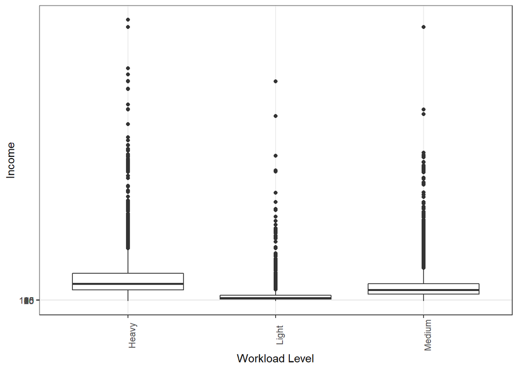

```r
ggplot(tract_data, aes(x = workload, y = PINCP)) +
  geom_boxplot() +
  theme_bw() +
  theme(axis.text.x = element_text(angle = 90)) +
  scale_x_discrete(name = "Workload Level") +
  scale_y_continuous(name = "Income",
                     breaks = seq(0, 105, by = 5),
                     labels = paste(prettyNum(seq(0, 105, by = 5),
                                              big.mark = ",")))
```

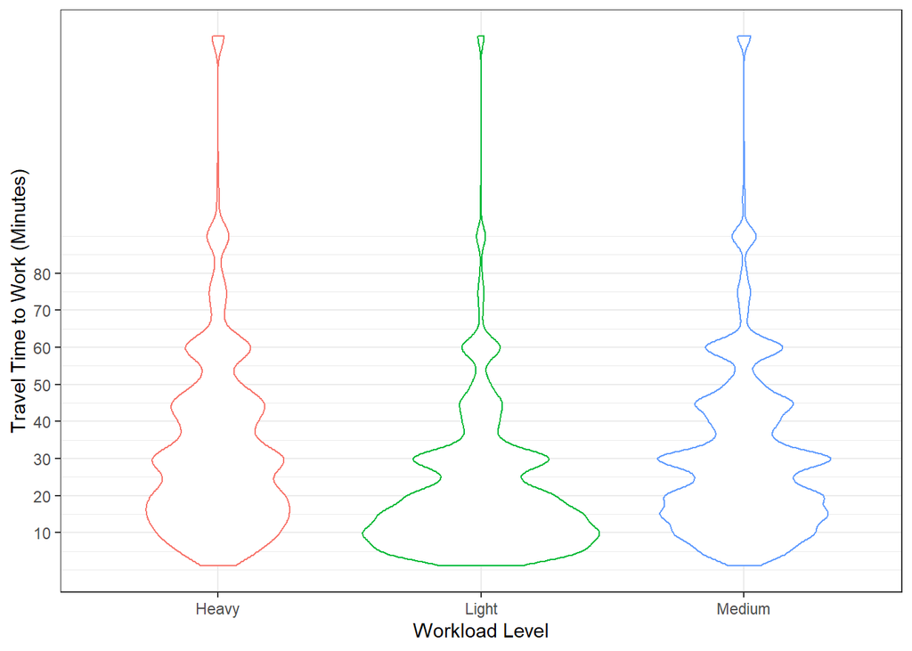

```r
ggplot(tract_data, aes(x = workload, y = JWMNP, color = workload)) +
  geom_violin() +
  scale_x_discrete(name = "Workload Level") +
  scale_y_continuous(name = "Travel Time to Work (Minutes)",
                     breaks = seq(10, 80, by = 10)) +
  theme_bw() +
  theme(legend.position = "none")
```

## Relationships between housing tenure type and continuous variables.

I use the anova test to find the relationship between housing tenure type and my continuous variables: income and travel time to work.

```r
anova <- aov (JWMNP ~ TEN_label, data = tract_data)
summary(anova)
```

```
##                Df   Sum Sq Mean Sq F value Pr(>F)
## TEN_label       4   334642   83660   153.3 <2e-16 ***
## Residuals   33436 18244983     546
## ---
## Signif. codes:  0 '***' 0.001 '**' 0.01 '*' 0.05 '.' 0.1 ' ' 1
```

```r
anova <- aov (PINCP ~ TEN_label, data = tract_data)
summary(anova)
```

```
##                Df    Sum Sq   Mean Sq F value Pr(>F)
## TEN_label       4 1.116e+13 2.789e+12   375.3 <2e-16 ***
## Residuals   33436 2.485e+14 7.431e+09
## ---
## Signif. codes:  0 '***' 0.001 '**' 0.01 '*' 0.05 '.' 0.1 ' ' 1
```

Difference Check:

```r
differences <- TukeyHSD(anova)
as_tibble(cbind(pair = row.names(differences$TEN_label),
                differences$TEN_label))
```

```
## # A tibble: 10 x 5
##    pair                              diff       lwr        upr       `p adj`
##    <chr>                             <chr>      <chr>      <chr>     <chr>
##  1 Occupied without payment of rent~ 35962.241~ 20021.506~ 51902.97~ 7.55610374~
##  2 Owned free and clear-N/A (GQ/vac~ 69857.444~ 61880.063~ 77834.82~ 0
##  3 Owned with mortgage or loan (inc~ 70804.096~ 63363.544~ 78244.64~ 0
##  4 Rented-N/A (GQ/vacant)            37447.748~ 29806.985~ 45088.51~ 0
##  5 Owned free and clear-Occupied wi~ 33895.202~ 19296.416~ 48493.98~ 2.39842090~
##  6 Owned with mortgage or loan (inc~ 34841.855~ 20529.351~ 49154.35~ 3.12785464~
##  7 Rented-Occupied without payment ~ 1485.5071~ -12932.09~ 15903.10~ 0.99863735~
##  8 Owned with mortgage or loan (inc~ 946.65268~ -2845.356~ 4738.662~ 0.96061606~
##  9 Rented-Owned free and clear       -32409.69~ -36580.88~ -28238.5~ 0
## 10 Rented-Owned with mortgage or lo~ -33356.34~ -36376.61~ -30336.0~ 0
```

I chose to display the relationship between housing tenure type and income using a box-plot in black & white, and the relationship between housing tenure type and travel time to work using a violin plot in colors. As the label names are too complicated, I relabeled them to shorter ones as well.

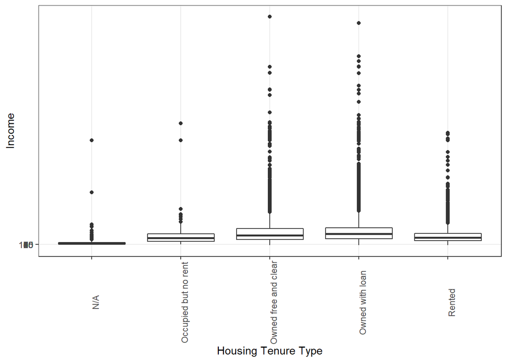

```r
ggplot(tract_data, aes(x = TEN_label, y = PINCP)) +
  geom_boxplot() +
  theme_bw() +
  theme(axis.text.x = element_text(angle = 90)) +
  scale_x_discrete(name = "Housing Tenure Type",
                   labels = c("N/A",
                              "Occupied but no rent",
                              "Owned free and clear",
                              "Owned with loan",
                              "Rented")) +
  scale_y_continuous(name = "Income",
                     breaks = seq(0, 105, by = 5),
                     labels = paste(prettyNum(seq(0, 105, by = 5),
                                              big.mark = ",")))
```

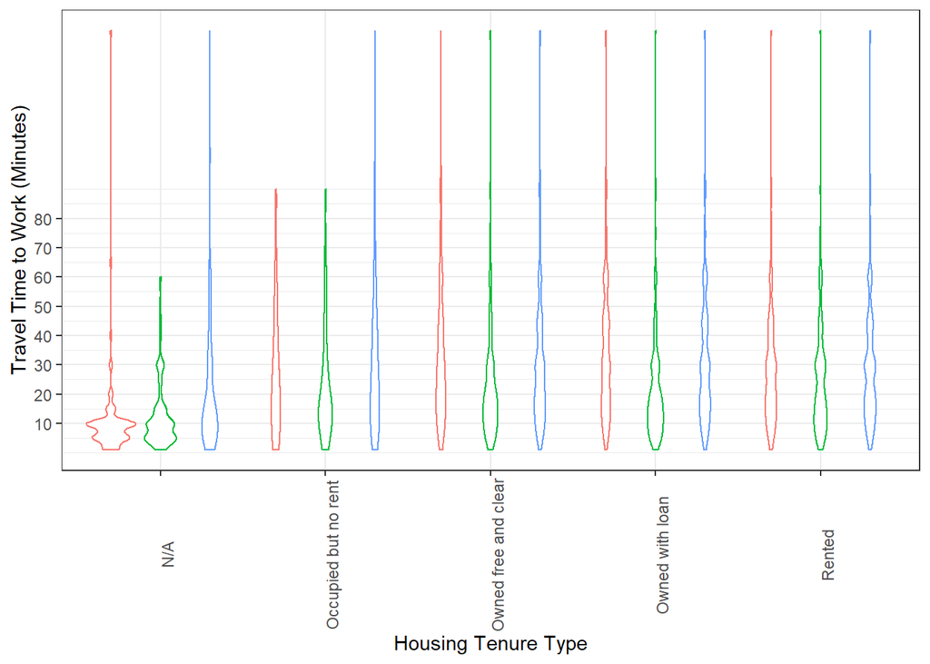

```r
ggplot(tract_data, aes(x = TEN_label, y = JWMNP, color = workload)) +
  geom_violin() +
  scale_x_discrete(name = "Housing Tenure Type",
                     labels = c("N/A",
                              "Occupied but no rent",
                              "Owned free and clear",
                              "Owned with loan",
                              "Rented")) +
  scale_y_continuous(name = "Travel Time to Work (Minutes)",
                     breaks = seq(10, 80, by = 10)) +
  theme_bw() +
  theme(axis.text.x = element_text(angle = 90)) +
  theme(legend.position = "none")
```

## Relationships between sex and continuous variables.

I use a two-sample t-test to find the relationship between sex and my continuous variables: income and travel time to work.

```r
difference1 = t.test(PINCP ~ SEX_label,
                    data = tract_data)
difference1
```

```
##
##  Welch Two Sample t-test
##
## data:  PINCP by SEX_label
## t = -33.428, df = 26961, p-value < 2.2e-16
## alternative hypothesis: true difference in means is not equal to 0
## 95 percent confidence interval:
##  -33473.45 -29765.46
## sample estimates:
## mean in group Female   mean in group Male
##             57079.91             88699.37
```

```r
difference2 = t.test(JWMNP ~ SEX_label,
                    data = tract_data)
difference2
```

```
##
##  Welch Two Sample t-test
##
## data:  JWMNP by SEX_label
## t = -13.537, df = 33209, p-value < 2.2e-16
## alternative hypothesis: true difference in means is not equal to 0
## 95 percent confidence interval:
##  -3.982660 -2.975238
## sample estimates:
## mean in group Female   mean in group Male
##             28.81765             32.29660
```

There is a significant relationship between sex and income at a 95% confidence level; tracts with a male group have a higher income. Also, there is a significant relationship between sex and travel time to work at a 95% confidence level; tracts with male group travel more time to work than the female group.

I chose to display the relationship between sex and income using a box-plot in black & white, and the relationship between sex and travel time to work using a violin plot in colors.

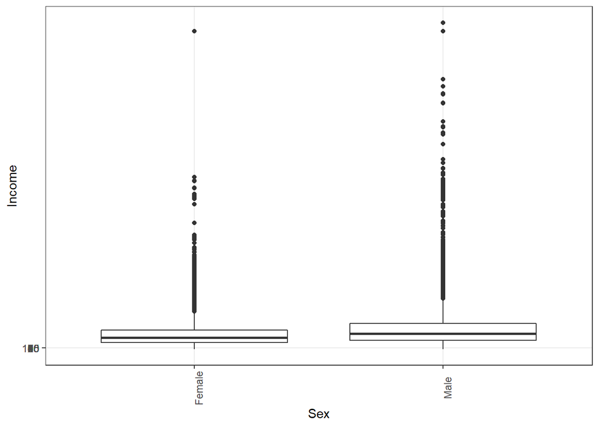

```r
ggplot(tract_data, aes(x = SEX_label, y = PINCP)) +
  geom_boxplot() +
  theme_bw() +
  theme(axis.text.x = element_text(angle = 90)) +
  scale_x_discrete(name = "Sex") +
  scale_y_continuous(name = "Income",
                     breaks = seq(0, 105, by = 5),
                     labels = paste(prettyNum(seq(0, 105, by = 5),
                                              big.mark = ",")))
```

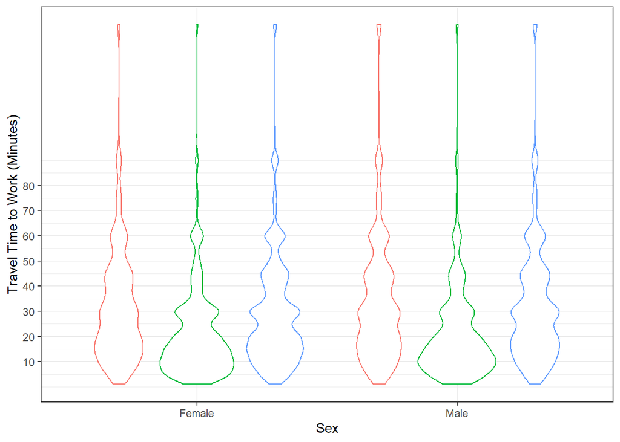

```r
ggplot(tract_data, aes(x = SEX_label, y = JWMNP, color = workload)) +
  geom_violin() +
  scale_x_discrete(name = "Sex") +
  scale_y_continuous(name = "Travel Time to Work (Minutes)",
                     breaks = seq(10, 80, by = 10)) +
  theme_bw() +
  theme(legend.position = "none")
```